# PigWeb: Oxytocin

Author

Liza Moscoviche & Anja Eggert

Published

January 27, 2025

# Libraries

```r
library(tidyverse)
library(kableExtra)
library(rstatix)
library(lmerTest)
library(car)
library(performance)
library(emmeans)
```

# Scripts, etc.

```r
contr = lmerControl(optimizer   = "bobyqa",
                    optCtrl     = list(maxfun = 10000000),
                    calc.derivs = FALSE)
```

```r
my_theme = theme_classic() +
  theme(text = element_text(family = "sans"),
        plot.title   = element_text(face = "plain", size = 16),
        axis.title   = element_text(face = "bold", size = 16),
        axis.text    = element_text(size = 14, angle = 0, vjust = 0.5),
        legend.title = element_text(face = "bold", size = 16),
        legend.text  = element_text(face = "plain", size = 16),
        strip.text   = element_text(size = 16),
        legend.position = "top",
        panel.grid.major = element_blank(),
        panel.grid.minor = element_blank())
```

```r
set.seed(1989)
```

# Data

## Read data

```r
dat <- read_csv("./data/PigWeb-physiology.csv",
                show_col_types = FALSE)
```

## Process data

```r
dat <- dat |>
  mutate(across(where(is.character), as.factor)) |>
  mutate(date           = dmy(date),
         date.f         = as.factor(date),
         time           = hms(time),
         institute      = fct_relevel(institute, "AU", "INRAE", "IRTA", "WUR"),
         institute      = relevel(institute, ref = "AU"),
         sample         = relevel(sample, ref = "pre"),
         context        = relevel(context, ref = "negative"),
         time_collect   = hour(time) + minute(time)/60,
         time_collect.z = as.vector(scale(time_collect)),
         space_allowance       = pen_space_m2/(group_weight_kg^0.66),
         space_allowance.log.z = as.vector(scale(log(space_allowance))))
```

# Oxytocin model: all 4 institutes

Analysis includes pre- and post-samples in both positive and negative context.

## Descriptive

```r
dat |>
  group_by(context, sample) |>
  get_summary_stats(oxyt_pgmL, show=c("median","q1","q3","iqr")) |>
  kable(caption = "Oxytocin data") |>
  kable_styling(bootstrap_options = c("striped", "hover"), font_size = 12) |>
  scroll_box(width = "800px")
```

Oxytocin data

| sample | context | variable | n | median | q1 | q3 | iqr |
| --- | --- | --- | --- | --- | --- | --- | --- |
| pre | negative | oxyt_pgmL | 115 | 131.794 | 80.346 | 174.598 | 94.253 |
| post | negative | oxyt_pgmL | 111 | 123.392 | 77.504 | 173.069 | 95.565 |
| pre | positive | oxyt_pgmL | 113 | 130.132 | 77.248 | 173.077 | 95.829 |
| post | positive | oxyt_pgmL | 106 | 118.336 | 82.206 | 164.459 | 82.253 |

## Defining model

Model with 2 interactions of fixed effects and random intercepts but constant slope.

Full model:

```r
mod.oxyt <- lmerTest::lmer(log(oxyt_pgmL) ~
                             sample * context +
                             sample * institute +
                             space_allowance.log.z +
                             time_collect.z +
                             (1|date.f) +
                             (1|pig_group_unique) +
                             (1|pig_id_unique),
                           data    = dat,
                           REML    = FALSE,
                           control = contr)
```

Reduced model, without interactions and without `sample` and `context`:

```r
mod.oxyt.red <- lmerTest::lmer(log(oxyt_pgmL) ~
                                 institute +
                                 space_allowance.log.z +
                                 time_collect.z +
                                 (1|date.f) +
                                 (1|pig_group_unique) +
                                 (1|pig_id_unique),
                               data    = dat,
                               REML    = FALSE,
                               control = contr)
```

Comparison of reduced and full model:

```r
anova(mod.oxyt.red, mod.oxyt, test = "Chisq")
```

```
Data: dat
Models:
mod.oxyt.red: log(oxyt_pgmL) ~ institute + space_allowance.log.z + time_collect.z + (1 | date.f) + (1 | pig_group_unique) + (1 | pig_id_unique)
mod.oxyt: log(oxyt_pgmL) ~ sample * context + sample * institute + space_allowance.log.z + time_collect.z + (1 | date.f) + (1 | pig_group_unique) + (1 | pig_id_unique)
             npar    AIC    BIC  logLik deviance  Chisq Df Pr(>Chisq)
mod.oxyt.red   10 450.80 491.78 -215.40   430.80
mod.oxyt       16 454.76 520.33 -211.38   422.76 8.0426  6      0.235
```

## Final model

Get effect estimates and standard errors of the model fitted with ML (`REML = FALSE`):

```r
round(summary(mod.oxyt)$coefficients, 2)
```

```
                           Estimate Std. Error     df t value Pr(>|t|)
(Intercept)                    4.67       0.12  43.11   40.43     0.00
samplepost                    -0.13       0.09 319.28   -1.48     0.14
contextpositive               -0.06       0.07 166.19   -0.92     0.36
instituteINRAE                 0.57       0.15  35.05    3.84     0.00
instituteIRTA                 -0.22       0.18  26.10   -1.19     0.25
instituteWUR                   0.14       0.14  39.64    1.00     0.32
space_allowance.log.z          0.00       0.05  18.53    0.05     0.96
time_collect.z                -0.01       0.03 178.51   -0.37     0.71
samplepost:contextpositive     0.00       0.07 321.59   -0.04     0.97
samplepost:instituteINRAE      0.25       0.11 325.33    2.36     0.02
samplepost:instituteIRTA       0.05       0.11 323.49    0.46     0.64
samplepost:instituteWUR        0.10       0.09 314.82    1.06     0.29
```

Get *p* values of fixed effects and interactions of the model fitted with REML (`REML = TRUE`). Using `drop1()`, for factors that are part of interactions, the main effect cannot be tested. In this case `car::Anova` can be used:

```r
round(drop1(mod.oxyt |> update(REML = TRUE),
            test = "Chisq"), 3)
```

```
Single term deletions using Satterthwaite's method:

Model:
log(oxyt_pgmL) ~ sample * context + sample * institute + space_allowance.log.z + time_collect.z + (1 | date.f) + (1 | pig_group_unique) + (1 | pig_id_unique)
                      Sum Sq Mean Sq NumDF  DenDF F value Pr(>F)
space_allowance.log.z  0.002   0.002     1  13.61   0.016  0.901
time_collect.z         0.013   0.013     1 179.37   0.115  0.735
sample:context         0.000   0.000     1 317.22   0.002  0.964
sample:institute       0.765   0.255     3 320.91   2.184  0.090 .
---
Signif. codes:  0 '***' 0.001 '**' 0.01 '*' 0.05 '.' 0.1 ' ' 1
```

```r
car::Anova(mod.oxyt |> update(REML = TRUE),
           test.statistic = "Chisq",
           type = 3) # as with interaction, otherwise set type = 2
```

```
Analysis of Deviance Table (Type III Wald chisquare tests)

Response: log(oxyt_pgmL)
                          Chisq Df Pr(>Chisq)
(Intercept)           1333.7221  1  < 2.2e-16 ***
sample                   2.1586  1  0.1417759
context                  1.1688  1  0.2796432
institute               21.0528  3  0.0001027 ***
space_allowance.log.z    0.0161  1  0.8991447
time_collect.z           0.1146  1  0.7349726
sample:context           0.0020  1  0.9642164
sample:institute         6.5513  3  0.0876606 .
---
Signif. codes:  0 '***' 0.001 '**' 0.01 '*' 0.05 '.' 0.1 ' ' 1
```

```r
car::Anova(mod.oxyt |> update(REML = TRUE),
           test.statistic = "F",
           type = 3) # as with interaction, otherwise set type = 2
```

```
Analysis of Deviance Table (Type III Wald F tests with Kenward-Roger df)

Response: log(oxyt_pgmL)
                              F Df Df.res    Pr(>F)
(Intercept)           1328.5626  1  30.83 < 2.2e-16 ***
sample                   2.1561  1 312.89  0.143006
context                  1.1058  1 159.51  0.294580
institute                6.9850  3  22.26  0.001754 **
space_allowance.log.z    0.0157  1  13.18  0.902047
time_collect.z           0.1092  1 182.18  0.741489
sample:context           0.0020  1 315.38  0.964272
sample:institute         2.1764  3 319.36  0.090711 .
---
Signif. codes:  0 '***' 0.001 '**' 0.01 '*' 0.05 '.' 0.1 ' ' 1
```

## Model diagnostics

Combined diagnostics:

```r
performance::check_model(mod.oxyt)
```

[output not shown]

Collinearity:

```r
xx=lm(log(oxyt_pgmL) ~
        sample +
        context +
        institute +
        space_allowance.log.z +
        time_collect.z,
      data = dat)
car::vif(xx)
```

```
                          GVIF Df GVIF^(1/(2*Df))
sample                1.062431  1        1.030743
context               1.167919  1        1.080703
institute             1.833364  3        1.106305
space_allowance.log.z 1.923217  1        1.386801
time_collect.z        1.150666  1        1.072691
```

## Emmeans

As interaction sample*institute is not significant, we compare here the 4 institutes:

```r
emmeans(mod.oxyt,
        pairwise ~ institute,
        data    = dat,
        adjust  = "tukey",
        lmer.df = "satterthwaite",
        type    = "response")$contrasts
```

```
 contrast     ratio     SE   df null t.ratio p.value
 AU / INRAE   0.499 0.0699 27.6    1  -4.962  0.0002
 AU / IRTA    1.213 0.2130 21.9    1   1.099  0.6940
 AU / WUR     0.829 0.1070 31.0    1  -1.454  0.4765
 INRAE / IRTA 2.430 0.3980 19.1    1   5.424  0.0002
 INRAE / WUR  1.661 0.2000 27.3    1   4.223  0.0013
 IRTA / WUR   0.684 0.1070 22.5    1  -2.441  0.0979

Results are averaged over the levels of: sample, context
Degrees-of-freedom method: satterthwaite
P value adjustment: tukey method for comparing a family of 4 estimates
Tests are performed on the log scale
```

# Oxytocin model: all 4 institutes, baseline

Analysis includes only pre-samples (“baseline”), but in both positive and negative context.

## Defining model

Full model:

```r
mod.oxyt <- lmerTest::lmer(log(oxyt_pgmL) ~
                             institute +
                             space_allowance.log.z +
                             time_collect.z +
                             (1|date.f) +
                             (1|pig_group_unique) +
                             (1|pig_id_unique),
                           data    = dat |> dplyr::filter(sample == "pre"),
                           REML    = FALSE,
                           control = contr)
```

Reduced model, with only random effects included:

```r
mod.oxyt.red <- lmerTest::lmer(log(oxyt_pgmL) ~
                                 (1|date.f) +
                                 (1|pig_group_unique) +
                                 (1|pig_id_unique),
                               data    = dat |> dplyr::filter(sample == "pre"),
                               REML    = FALSE,
                               control = contr)
```

Comparison of reduced and full model:

```r
anova(mod.oxyt.red, mod.oxyt, test = "Chisq")
```

```
Data: dplyr::filter(dat, sample == "pre")
Models:
mod.oxyt.red: log(oxyt_pgmL) ~ (1 | date.f) + (1 | pig_group_unique) + (1 | pig_id_unique)
mod.oxyt: log(oxyt_pgmL) ~ institute + space_allowance.log.z + time_collect.z + (1 | date.f) + (1 | pig_group_unique) + (1 | pig_id_unique)
             npar    AIC    BIC  logLik deviance  Chisq Df Pr(>Chisq)
mod.oxyt.red    5 244.39 261.54 -117.20   234.39
mod.oxyt       10 236.98 271.28 -108.49   216.98 17.411  5   0.003783 **
---
Signif. codes:  0 '***' 0.001 '**' 0.01 '*' 0.05 '.' 0.1 ' ' 1
```

## Final model

Get effect estimates and standard errors of the model fitted with ML (`REML = FALSE`):

```r
round(summary(mod.oxyt)$coefficients, 2)
```

```
                      Estimate Std. Error     df t value Pr(>|t|)
(Intercept)               4.62       0.12  29.79   38.26     0.00
instituteINRAE            0.58       0.16  26.06    3.60     0.00
instituteIRTA            -0.21       0.20  20.39   -1.04     0.31
instituteWUR              0.15       0.15  29.46    1.04     0.31
space_allowance.log.z     0.01       0.05  15.26    0.28     0.78
time_collect.z           -0.04       0.03 117.04   -1.10     0.27
```

Get *p* values of fixed effects and interactions of the model fitted with REML (`REML = TRUE`). Using `drop1()`, for factors that are part of interactions, the main effect cannot be tested. In this case `car::Anova` can be used:

```r
round(drop1(mod.oxyt |> update(REML = TRUE),
            test = "Chisq"), 3)
```

```
Single term deletions using Satterthwaite's method:

Model:
log(oxyt_pgmL) ~ institute + space_allowance.log.z + time_collect.z + (1 | date.f) + (1 | pig_group_unique) + (1 | pig_id_unique)
                      Sum Sq Mean Sq NumDF   DenDF F value Pr(>F)
institute              1.595   0.532     3  18.015   5.832  0.006 **
space_allowance.log.z  0.007   0.007     1  11.530   0.081  0.781
time_collect.z         0.099   0.099     1 116.254   1.091  0.298
---
Signif. codes:  0 '***' 0.001 '**' 0.01 '*' 0.05 '.' 0.1 ' ' 1
```

```r
car::Anova(mod.oxyt |> update(REML = TRUE),
           test.statistic = "Chisq",
           type = 3) # as with interaction, otherwise set type = 2
```

```
Analysis of Deviance Table (Type III Wald chisquare tests)

Response: log(oxyt_pgmL)
                          Chisq Df Pr(>Chisq)
(Intercept)           1164.3267  1  < 2.2e-16 ***
institute               17.4975  3  0.0005583 ***
space_allowance.log.z    0.0808  1  0.7761681
time_collect.z           1.0909  1  0.2962820
---
Signif. codes:  0 '***' 0.001 '**' 0.01 '*' 0.05 '.' 0.1 ' ' 1
```

```r
car::Anova(mod.oxyt |> update(REML = TRUE),
           test.statistic = "F",
           type = 3) # as with interaction, otherwise set type = 2
```

```
Analysis of Deviance Table (Type III Wald F tests with Kenward-Roger df)

Response: log(oxyt_pgmL)
                              F Df  Df.res    Pr(>F)
(Intercept)           1162.1452  1  23.894 < 2.2e-16 ***
institute                5.8012  3  18.888  0.005492 **
space_allowance.log.z    0.0794  1  10.971  0.783402
time_collect.z           1.0275  1 115.017  0.312880
---
Signif. codes:  0 '***' 0.001 '**' 0.01 '*' 0.05 '.' 0.1 ' ' 1
```

## Model diagnostics

Combined diagnostics:

```r
performance::check_model(mod.oxyt)
```

[output not shown]

Collinearity:

```r
xx=lm(log(oxyt_pgmL) ~
        institute +
        space_allowance.log.z +
        time_collect.z,
      data = dat |> dplyr::filter(sample == "pre"))
car::vif(xx)
```

```
                          GVIF Df GVIF^(1/(2*Df))
institute             1.788218  3        1.101717
space_allowance.log.z 1.668025  1        1.291520
time_collect.z        1.109283  1        1.053225
```

## Emmeans

As interaction sample*institute is not significant, we compare here the 4 institutes:

```r
emmeans(mod.oxyt,
        pairwise ~ institute,
        data    = dat |> dplyr::filter(sample == "pre"),
        adjust  = "tukey",
        lmer.df = "satterthwaite",
        type    = "response")$contrasts
```

```
 contrast     ratio     SE   df null t.ratio p.value
 AU / INRAE   0.562 0.0899 26.1    1  -3.604  0.0067
 AU / IRTA    1.230 0.2450 20.4    1   1.040  0.7282
 AU / WUR     0.857 0.1270 29.5    1  -1.043  0.7259
 INRAE / IRTA 2.189 0.4100 18.4    1   4.190  0.0027
 INRAE / WUR  1.525 0.2090 25.6    1   3.084  0.0235
 IRTA / WUR   0.697 0.1240 21.5    1  -2.034  0.2071

Degrees-of-freedom method: satterthwaite
P value adjustment: tukey method for comparing a family of 4 estimates
Tests are performed on the log scale
```

# Oxytocin model: all 2 institutes, violation of expectations

Analysis includes pre- and post-samples in both positive and negative context of a subset, only AU and IRTA.

## Descriptive

```r
dat |>
  dplyr::filter(violation_expectations == "yes") |>
  group_by(context, sample) |>
  get_summary_stats(oxyt_pgmL, show=c("median","q1","q3","iqr")) |>
  kable(caption = "Oxytocin data") |>
  kable_styling(bootstrap_options = c("striped", "hover"), font_size = 12) |>
  scroll_box(width = "800px")
```

Oxytocin data

| sample | context | variable | n | median | q1 | q3 | iqr |
| --- | --- | --- | --- | --- | --- | --- | --- |
| pre | negative | oxyt_pgmL | 30 | 129.378 | 77.621 | 160.637 | 83.017 |
| post | negative | oxyt_pgmL | 29 | 77.732 | 59.206 | 123.392 | 64.186 |
| pre | positive | oxyt_pgmL | 31 | 89.506 | 68.562 | 132.776 | 64.214 |
| post | positive | oxyt_pgmL | 29 | 93.593 | 65.561 | 121.038 | 55.477 |

## Defining model

Model with 1 interaction of fixed effects and random intercepts but constant slope.

Full model:

```r
mod.oxyt <- lmerTest::lmer(log(oxyt_pgmL) ~
                             sample * context +
                             institute +
                             space_allowance.log.z +
                             time_collect.z +
                             (1|date.f) +
                             (1|pig_group_unique) +
                             (1|pig_id_unique),
                           data    = dat |> dplyr::filter(violation_expectations == "yes"),
                           REML    = FALSE,
                           control = contr)
```

Reduced model, without interactions and without `sample` and `context`:

```r
mod.oxyt.red <- lmerTest::lmer(log(oxyt_pgmL) ~
                                 institute +
                                 space_allowance.log.z +
                                 time_collect.z +
                                 (1|date.f) +
                                 (1|pig_group_unique) +
                                 (1|pig_id_unique),
                               data    = dat |> dplyr::filter(violation_expectations == "yes"),
                               REML    = FALSE,
                               control = contr)
```

Comparison of reduced and full model:

```r
anova(mod.oxyt.red, mod.oxyt, test = "Chisq")
```

```
Data: dplyr::filter(dat, violation_expectations == "yes")
Models:
mod.oxyt.red: log(oxyt_pgmL) ~ institute + space_allowance.log.z + time_collect.z + (1 | date.f) + (1 | pig_group_unique) + (1 | pig_id_unique)
mod.oxyt: log(oxyt_pgmL) ~ sample * context + institute + space_allowance.log.z + time_collect.z + (1 | date.f) + (1 | pig_group_unique) + (1 | pig_id_unique)
             npar    AIC    BIC  logLik deviance  Chisq Df Pr(>Chisq)
mod.oxyt.red    8 136.49 158.72 -60.245   120.49
mod.oxyt       11 131.39 161.96 -54.695   109.39 11.101  3    0.01119 *
---
Signif. codes:  0 '***' 0.001 '**' 0.01 '*' 0.05 '.' 0.1 ' ' 1
```

## Final model

Get effect estimates and standard errors of the model fitted with ML (`REML = FALSE`):

```r
round(summary(mod.oxyt)$coefficients, 2)
```

```
                           Estimate Std. Error    df t value Pr(>|t|)
(Intercept)                    4.28       0.74 14.09    5.80     0.00
samplepost                    -0.37       0.11 90.34   -3.27     0.00
contextpositive               -0.18       0.15  6.86   -1.24     0.26
instituteIRTA                  2.19       3.22 14.37    0.68     0.51
space_allowance.log.z          1.41       1.97 14.46    0.72     0.48
time_collect.z                 0.13       0.12 40.42    1.07     0.29
samplepost:contextpositive     0.31       0.12 85.92    2.62     0.01
```

Get *p* values of fixed effects and interactions of the model fitted with REML (`REML = TRUE`). Using `drop1()`, for factors that are part of interactions, the main effect cannot be tested. In this case `car::Anova` can be used:

```r
round(drop1(mod.oxyt |> update(REML = TRUE),
            test = "Chisq"), 3)
```

```
Single term deletions using Satterthwaite's method:

Model:
log(oxyt_pgmL) ~ sample * context + institute + space_allowance.log.z + time_collect.z + (1 | date.f) + (1 | pig_group_unique) + (1 | pig_id_unique)
                      Sum Sq Mean Sq NumDF  DenDF F value Pr(>F)
institute              0.047   0.047     1 11.057   0.442  0.520
space_allowance.log.z  0.051   0.051     1 11.118   0.483  0.501
time_collect.z         0.070   0.070     1 37.168   0.665  0.420
sample:context         0.711   0.711     1 84.050   6.719  0.011 *
---
Signif. codes:  0 '***' 0.001 '**' 0.01 '*' 0.05 '.' 0.1 ' ' 1
```

```r
car::Anova(mod.oxyt |> update(REML = TRUE),
           test.statistic = "Chisq",
           type = 3) # as with interaction, otherwise set type = 2
```

```
Analysis of Deviance Table (Type III Wald chisquare tests)

Response: log(oxyt_pgmL)
                        Chisq Df Pr(>Chisq)
(Intercept)           22.8489  1  1.752e-06 ***
sample                 9.1374  1   0.002504 **
context                0.7981  1   0.371663
institute              0.4421  1   0.506094
space_allowance.log.z  0.4833  1   0.486927
time_collect.z         0.6649  1   0.414828
sample:context         6.7189  1   0.009539 **
---
Signif. codes:  0 '***' 0.001 '**' 0.01 '*' 0.05 '.' 0.1 ' ' 1
```

```r
car::Anova(mod.oxyt |> update(REML = TRUE),
           test.statistic = "F",
           type = 3) # as with interaction, otherwise set type = 2
```

```
Analysis of Deviance Table (Type III Wald F tests with Kenward-Roger df)

Response: log(oxyt_pgmL)
                            F Df Df.res  Pr(>F)
(Intercept)           19.2154  1 10.465 0.00123 **
sample                 8.3834  1 78.649 0.00490 **
context                0.7978  1  2.572 0.44735
institute              0.3680  1 10.687 0.55674
space_allowance.log.z  0.4019  1 10.742 0.53938
time_collect.z         0.5581  1 35.498 0.45996
sample:context         6.7096  1 83.353 0.01132 *
---
Signif. codes:  0 '***' 0.001 '**' 0.01 '*' 0.05 '.' 0.1 ' ' 1
```

## Model diagnostics

Combined diagnostics:

```r
performance::check_model(mod.oxyt)
```

[output not shown]

Collinearity:

```r
xx=lm(log(oxyt_pgmL) ~
        sample +
        context +
        institute +
        space_allowance.log.z +
        time_collect.z,
      data = dat)
car::vif(xx)
```

```
                          GVIF Df GVIF^(1/(2*Df))
sample                1.062431  1        1.030743
context               1.167919  1        1.080703
institute             1.833364  3        1.106305
space_allowance.log.z 1.923217  1        1.386801
time_collect.z        1.150666  1        1.072691
```

## Emmeans

```r
emmeans(mod.oxyt,
        pairwise ~ sample|context,
        data    = dat |> dplyr::filter(violation_expectations == "yes"),
        adjust  = "tukey",
        lmer.df = "satterthwaite",
        type    = "response")$contrasts
```

```
context = negative:
 contrast   ratio    SE   df null t.ratio p.value
 pre / post  1.44 0.161 90.3    1   3.273  0.0015

context = positive:
 contrast   ratio    SE   df null t.ratio p.value
 pre / post  1.06 0.116 94.7    1   0.508  0.6123

Results are averaged over the levels of: institute
Degrees-of-freedom method: satterthwaite
Tests are performed on the log scale
```

# Figures

## Suppl. Figure 2: Log-Oxytocin all 4 institutes

```r
plot <- dat |>
  mutate(jit = jitter(as.numeric(sample), 0.3)) |>

  ggplot(aes(y = log(oxyt_pgmL))) +
  geom_boxplot(aes(x = sample),
               col = "black", fill = NA,
               outlier.shape = NA, width=0.5,
               position = position_dodge(0.5)) +
  geom_line(aes(x = jit, group = pig_id_unique),
            col = "grey80", linewidth = 0.2) +
  geom_point(aes(x = jit,
                 col = institute,
                 shape = institute),
             size = 2.5, alpha = 0.7) +
  scale_colour_manual(values = c("#481568FF", "#32648EFF", "#94D840FF", "#FDE725FF")) +
  scale_shape_manual(values = c(17, 15, 16, 18)) +
  facet_wrap(~ context) +
  labs(x   = "Sample type",
       y   = "log(oxytocin) (pg/ml)",
       # Matching title ensures a single legend
       col = "Institutes",
       shape = "Institutes") +
  my_theme
```

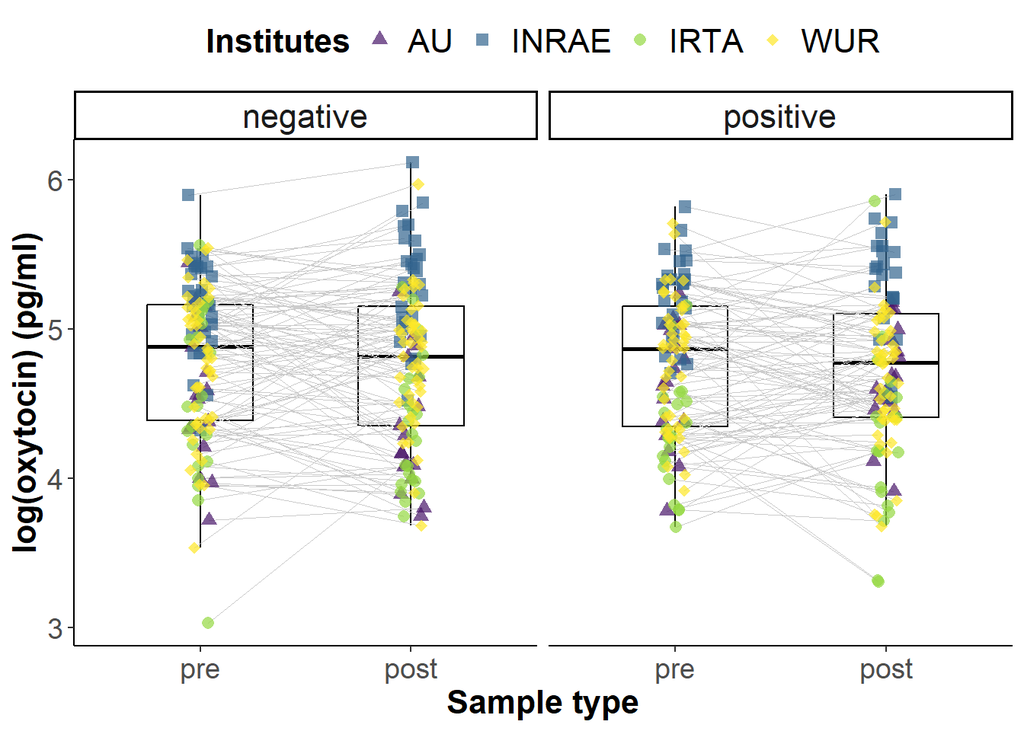

```r
plot
```

```r
png("./plots/oxyt-log-context-sample-institute.png",
    width = 200, height = 180, units = "mm",
    pointsize = 10, res = 600)

plot

dev.off()
```

## Figure 7: Oxytocin (violating expectations) AU+IRTA

```r
plot <- dat |>
  dplyr::filter(violation_expectations == "yes") |>
  mutate(jit = jitter(as.numeric(sample), 0.3))  |>

  ggplot(aes(y = oxyt_pgmL)) +
  geom_boxplot(aes(x = sample),
               col = "black", fill = NA,
               outlier.shape = NA, width=0.5,
               position = position_dodge(0.5)) +
  geom_line(aes(x = jit, group = pig_id_unique),
            col = "grey80", linewidth = 0.2) +
  geom_point(aes(x = jit,
                 col = institute,
                 shape = institute),
             size = 2.5, alpha = 0.7) +
  scale_colour_manual(values = c("#481568FF", "#94D840FF")) +
  scale_shape_manual(values = c(17, 16)) +
  facet_wrap(~ context) +
  labs(x   = "Sample type",
       y   = "Oxytocin (pg/ml)",
       # Matching title ensures a single legend
       col = "Institutes",
       shape = "Institutes") +
  my_theme
```

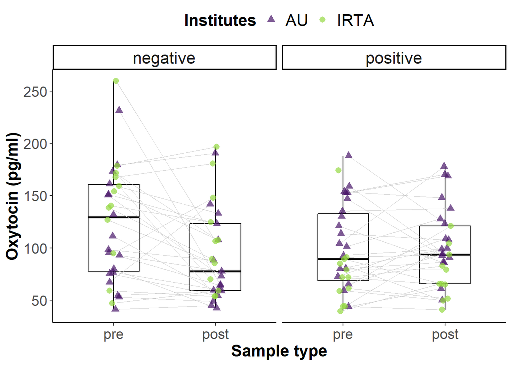

```r
plot
```

```r
png("./plots/oxyt-viol-exp-context-type.png",
    width = 200, height = 180, units = "mm",
    pointsize = 10, res = 600)

plot

dev.off()
```

# Citing R

“All analyses were performed using R Statistical Software (version 4.4.2; R Core Team 2024)”.

Reference: R Core Team (2024). R: A language and environment for statistical computing. R Foundation for Statistical Computing, Vienna, Austria. URL https://www.R-project.org/.

```r
citation()
```

```
  R Core Team (2024). _R: A Language and Environment for Statistical
  Computing_. R Foundation for Statistical Computing, Vienna, Austria.
  <https://www.R-project.org/>.

Ein BibTeX-Eintrag für LaTeX-Benutzer ist

  @Manual{,
    title = {R: A Language and Environment for Statistical Computing},
    author = {{R Core Team}},
    organization = {R Foundation for Statistical Computing},
    address = {Vienna, Austria},
    year = {2024},
    url = {https://www.R-project.org/},
  }

We have invested a lot of time and effort in creating R, please cite it
when using it for data analysis. See also 'citation("pkgname")' for
citing R packages.
```

```r
version$version.string
```

```
[1] "R version 4.4.2 (2024-10-31 ucrt)"
```

```r
citation("tidyverse")
```

```
Um Paket 'tidyverse' in Publikationen zu zitieren, nutzen Sie bitte:

  Wickham H, Averick M, Bryan J, Chang W, McGowan LD, François R,
  Grolemund G, Hayes A, Henry L, Hester J, Kuhn M, Pedersen TL, Miller
  E, Bache SM, Müller K, Ooms J, Robinson D, Seidel DP, Spinu V,
  Takahashi K, Vaughan D, Wilke C, Woo K, Yutani H (2019). "Welcome to
  the tidyverse." _Journal of Open Source Software_, *4*(43), 1686.
  doi:10.21105/joss.01686 <https://doi.org/10.21105/joss.01686>.

Ein BibTeX-Eintrag für LaTeX-Benutzer ist

  @Article{,
    title = {Welcome to the {tidyverse}},
    author = {Hadley Wickham and Mara Averick and Jennifer Bryan and Winston Chang and Lucy D'Agostino McGowan and Romain François and Garrett Grolemund and Alex Hayes and Lionel Henry and Jim Hester and Max Kuhn and Thomas Lin Pedersen and Evan Miller and Stephan Milton Bache and Kirill Müller and …
    year = {2019},
    journal = {Journal of Open Source Software},
    volume = {4},
    number = {43},
    pages = {1686},
    doi = {10.21105/joss.01686},
  }
```

```r
citation("lmerTest")
```

```
  Kuznetsova A, Brockhoff PB, Christensen RHB (2017). "lmerTest
  Package: Tests in Linear Mixed Effects Models." _Journal of
  Statistical Software_, *82*(13), 1-26. doi:10.18637/jss.v082.i13
  <https://doi.org/10.18637/jss.v082.i13>.

Ein BibTeX-Eintrag für LaTeX-Benutzer ist

  @Article{,
    title = {{lmerTest} Package: Tests in Linear Mixed Effects Models},
    author = {Alexandra Kuznetsova and Per B. Brockhoff and Rune H. B. Christensen},
    journal = {Journal of Statistical Software},
    year = {2017},
    volume = {82},
    number = {13},
    pages = {1--26},
    doi = {10.18637/jss.v082.i13},
  }
```

```r
citation("car")
```

```
  Fox J, Weisberg S (2019). _An R Companion to Applied Regression_,
  Third edition. Sage, Thousand Oaks CA.
  <https://www.john-fox.ca/Companion/>.

Ein BibTeX-Eintrag für LaTeX-Benutzer ist

  @Book{,
    title = {An {R} Companion to Applied Regression},
    edition = {Third},
    author = {John Fox and Sanford Weisberg},
    year = {2019},
    publisher = {Sage},
    address = {Thousand Oaks {CA}},
    url = {https://www.john-fox.ca/Companion/},
  }
```

```r
citation("performance")
```

```
Um Paket 'performance' in Publikationen zu zitieren, nutzen Sie bitte:

  Lüdecke et al., (2021). performance: An R Package for Assessment,
  Comparison and Testing of Statistical Models. Journal of Open Source
  Software, 6(60), 3139. https://doi.org/10.21105/joss.03139

Ein BibTeX-Eintrag für LaTeX-Benutzer ist

  @Article{,
    title = {{performance}: An {R} Package for Assessment, Comparison and Testing of Statistical Models},
    author = {Daniel Lüdecke and Mattan S. Ben-Shachar and Indrajeet Patil and Philip Waggoner and Dominique Makowski},
    year = {2021},
    journal = {Journal of Open Source Software},
    volume = {6},
    number = {60},
    pages = {3139},
    doi = {10.21105/joss.03139},
  }
```

```r
citation("emmeans")
```

```
Um Paket 'emmeans' in Publikationen zu zitieren, nutzen Sie bitte:

  Lenth R (2024). _emmeans: Estimated Marginal Means, aka Least-Squares
  Means_. R package version 1.10.6,
  <https://CRAN.R-project.org/package=emmeans>.

Ein BibTeX-Eintrag für LaTeX-Benutzer ist

  @Manual{,
    title = {emmeans: Estimated Marginal Means, aka Least-Squares Means},
    author = {Russell V. Lenth},
    year = {2024},
    note = {R package version 1.10.6},
    url = {https://CRAN.R-project.org/package=emmeans},
  }
```